# Demographic Breast Cancer Predictions for Targeted Interventions

Author

SID 550713797

# Client Bio

**Client:** [National Breast Cancer Foundation (NBCF)](https://nbcf.org.au/about/)

[figure not shown]

**Bio**: The National Breast Cancer Foundation is an Australian non-profit organisation dedicated in funding life-saving breast cancer research. NBCF has invested in innovative research to improve prevention, diagnosis, treatment of breast cancer patients, with the goal of achieving zero deaths from breast cancer by 2030.

# Recommendation

To increase the predictability of breast cancer patients, NBCF should conduct analysis on the influence of demographic and stage variables on breast cancer outcomes. This can aid in identifying high-risk population and enable precise treatments while spreading awareness, resulting in a likelihood in reducing breast cancer mortality.

# Evidence

The data analysed in this research is sourced from SEER Breast Cancer Data (IEEEDataPort), contributed by JING TENG. The dataset involves 4024 female patients, including various features on their demographic and cancer status.

```r
library(tidyverse)
library(ggplot2)
library(survival)
library(survminer)
library(ggiraph)
library(plotly)

raw_data = read.csv("breast_cancer.csv")

#Convert Grade into integer format
data = raw_data %>% mutate(Grade = case_when(
str_detect(Grade, "1") ~ 1L,
str_detect(Grade, "2") ~ 2L,
str_detect(Grade, "3") ~ 3L,
str_detect(Grade, regex("anaplastic; grade iv", ignore_case = TRUE)) ~ 4L
))
```

# Survival Months by Age groups, Race, and Marital Status

**Age Group**

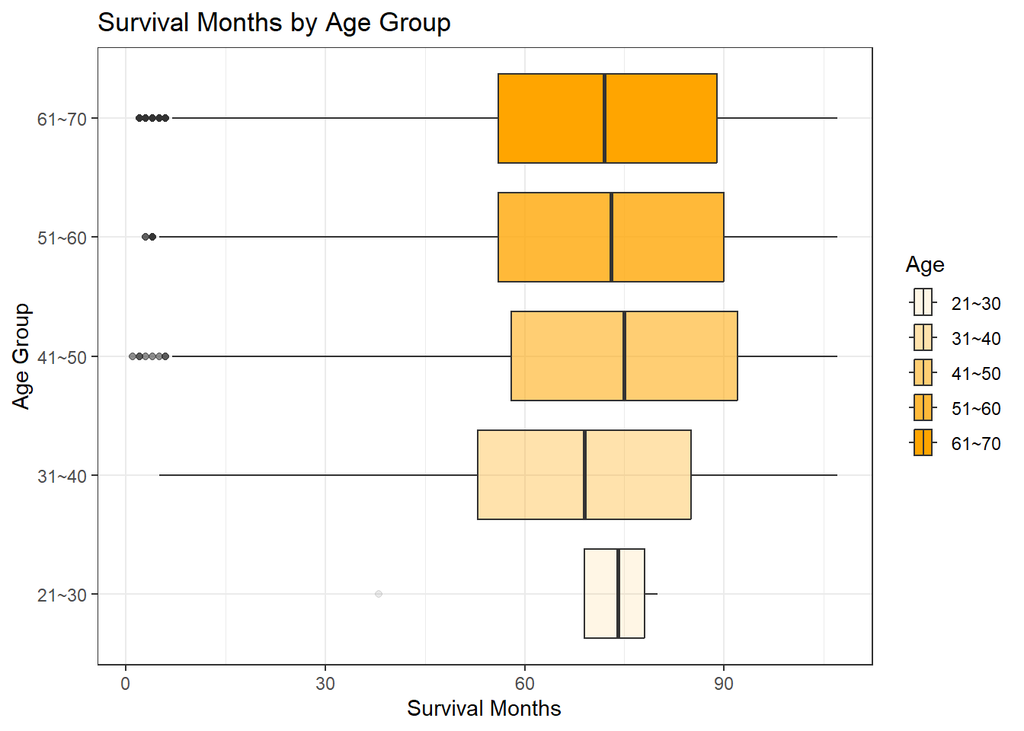

```r
split_age = data %>% mutate(Age = case_when(
  Age > 0 & Age <= 10 ~ "1~10",
  Age > 10 & Age <= 20 ~ "11~20",
  Age > 20 & Age <= 30 ~ "21~30",
  Age > 30 & Age <= 40 ~ "31~40",
  Age > 40 & Age <= 50 ~ "41~50",
  Age > 50 & Age <= 60 ~ "51~60",
  Age > 60 & Age <= 70 ~ "61~70",
  Age > 70 & Age <= 80 ~ "71~80",
  Age > 80 & Age <= 90 ~ "81~90",
  Age > 90 & Age <= 100 ~ "91~100",
  Age > 100 ~ ">100"
))

ggplot(split_age, aes(x = Survival.Months, y = Age, alpha = Age)) +
  labs(title = "Survival Months by Age Group", x ="Survival Months", y = "Age Group") +
  geom_boxplot(fill="orange") +
  theme(plot.title = element_text(hjust = 0.5, size = 16)) +
  theme_bw()
```

**Race**

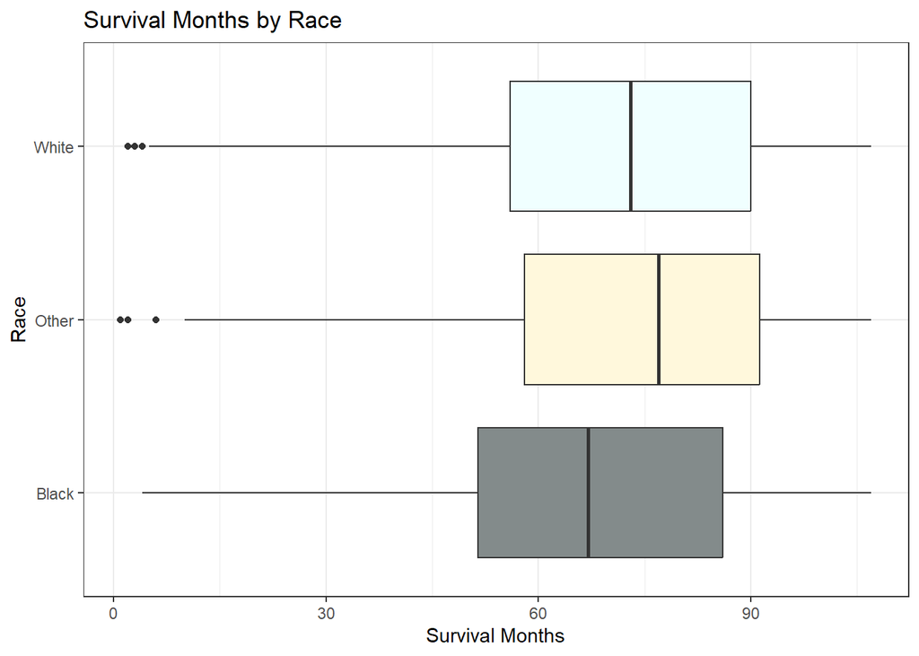

```r
ggplot(data, aes(x = Survival.Months, y = Race)) +
  labs(title = "Survival Months by Race", x = "Survival Months", y = "Race") +
  geom_boxplot(fill = c("azure4","cornsilk","azure1"), ) +
  theme(plot.title = element_text(hjust = 0.5, size = 16)) +
  theme_bw()
```

**Marital Status**

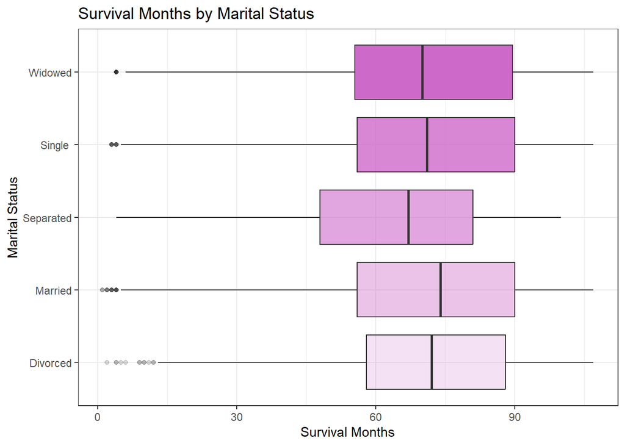

```r
ggplot(data, aes(x = Survival.Months, y = Marital.Status)) +
  labs(title = "Survival Months by Marital Status", x = "Survival Months", y = "Marital Status") +
  geom_boxplot(fill = "orchid3", alpha = c(0.2,0.4,0.6,0.8,1)) +
  theme(plot.title = element_text(hjust = 0.5, size = 16)) +
  theme_bw()
```

```r
#fivenum(filter(data, Marital.Status == "Separated")$Survival.Months)
#fivenum(filter(data, Marital.Status != "Separated")$Survival.Months)
```